# Problema 3 - Checkpoint 1 AD1 UFCG

Diogo Florêncio

```r
require(GGally, quietly = TRUE)
require(reshape2, quietly = TRUE)
require(tidyverse, quietly = TRUE, warn.conflicts = FALSE)
library(ggfortify)
library(cluster)
library(ggdendro)
library(broom)
library(tidyverse)
library(plotly)
```

Os dados escolhidos para este laboratório são referentes as unidades acadêmicas da UFCG. Analisando os dados de modo geral, observei a existência de algumas unidades acadêmicas que possuem 1,2 ou 3 funcionários, valores estranhos. Deste modo, considerei apenas unidades acadêmicas que possuem mais de 10 funcionários.

```r
dados <- read.csv("../dados/ufcg-201704-sumario-UAs-wide.csv",encoding="UTF-8")
dados <- dados %>%
  group_by(unidade_academica = UORG_LOTACAO) %>%
   summarise(total_funcionarios = sum(Outro,Professor.20h,Professor.40h.ou.DE),
              Professor.40h.ou.DE = Professor.40h.ou.DE,
              #Professor.20h = Professor.20h,
              idade_mediana = idade_mediana)%>%
  filter(total_funcionarios > 10) %>%
  ungroup()
```

As variáveis escolhidas para o agrupamento foram `total de funcionários`, `Professor.40h.ou.DE` e `idade_mediana`(50 percentil da idade dos funcionários); uma descrição mais detalhada sobre os dados está disponível [aqui](https://github.com/nazareno/tamanhos-da-ufcg). As escalas originais das variáveis apresentam uma diferença significativa em seus valores, deste modo foram normalizadas prevenindo que uma variável domine a análise.

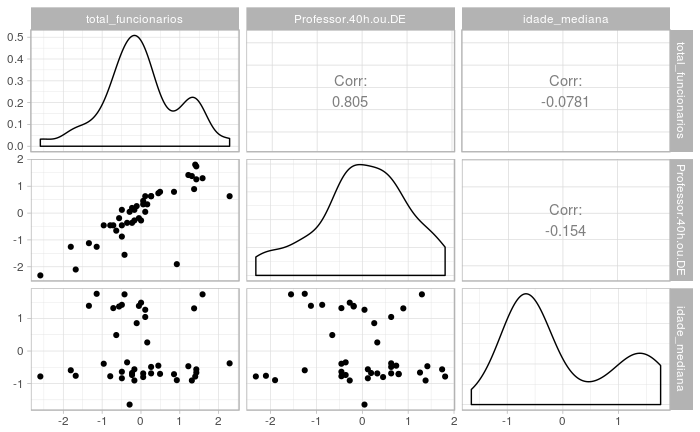

```r
dados.scaled = dados %>%
    mutate_each(funs(log), 2:4) %>%
    mutate_each(funs(as.vector(scale(.))), 2:4)
dados.scaled %>%
    select(-unidade_academica) %>%
    ggpairs()
```

Pode-se definir o número de `clusters` do agrupamento, por meio do calculo da distância quadrática entre o centro dos clusters, o centro dos dados e os dados. Aqui o centro dos dados é um ponto imaginário na média de todas as variáveis. O gráfico relaciona as variáveis `betweenss` e `totss`, essa proporção pode ser usada para definir um bom valor para o número de `clusters`. Quando ela para de crescer, para de valer à pena aumentar os `clusters`. Neste caso, um bom valor para o número de `clusters`seria 4.

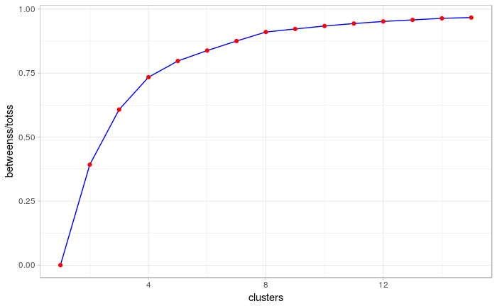

```r
set.seed(123)
explorando_clusters = tibble(clusters = 1:15) %>%
    group_by(clusters) %>%
    do(
        kmeans(select(dados.scaled, -unidade_academica),
               centers = .$clusters,
               nstart = 20) %>% glance()
    )
explorando_clusters %>%
    ggplot(aes(x = clusters, y = betweenss / totss)) +
    geom_line(color = "blue") +
    geom_point(color = "red")
```

## Agrupamento k- means

Após definir a quantidades de clusters do agrupamento, agrapamento foi realizado através do método de clustering `k- means`.

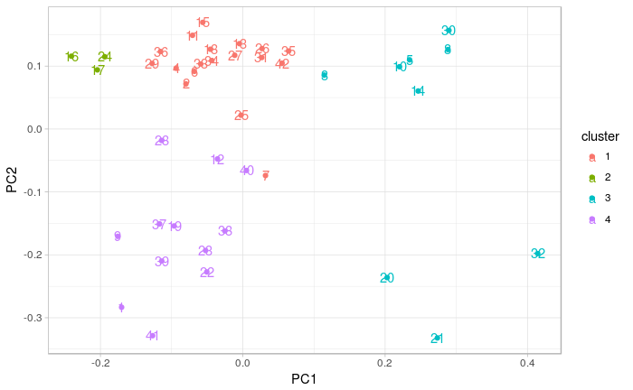

```r
set.seed(123)
n_clusters = 4
km = dados.scaled %>%
    select(-unidade_academica) %>%
    kmeans(centers = n_clusters, nstart = 20)
dados.long = km %>%
    augment(dados.scaled) %>%
    gather(key = "variável",
           value = "valor",
           -unidade_academica, -.cluster)
autoplot(km, data = dados, label = TRUE)
```

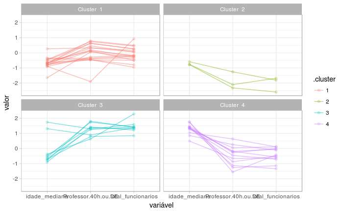

```r
dados.long %>%
    ggplot(aes(x = `variável`, y = valor, group = unidade_academica, colour = .cluster)) +
    geom_point(alpha = 0.2) +
    geom_line(alpha = .5) +
    facet_wrap(~ paste("Cluster ",.cluster))
```

```r
km %>%
    augment(dados) %>%
    plot_ly(type = 'parcoords',
            line = list(color = ~.cluster,
                        showScale = TRUE),
            dimensions = list(
                list(label = 'Total_funcionarios/UA', values = ~total_funcionarios),
                list(label = 'idade_mediana/UA', values = ~idade_mediana),
                list(label = 'Professor.40h.ou.DE/UA', values = ~Professor.40h.ou.DE)
            )
    )
```

[interactive chart not shown]